# S1_Informe

# Modelos probabilísticos:

## Modelo binomial para variable Motivo

Objetivo: Plantear un modelo probabilístico de acuerdo con un modelo de comportamiento de la variable motivo de acuerdo con la recomendación de compra.

Proceso de identificación:

La variable Motivo es una variable aleatoria discreta ya que puede tomar un número finito de valores numerables. Por lo cual se consideró realizar el modelo de distribución binomial, para ello la agrupación en 2 categorías para esta variable, tanto en éxito y fracaso. De los cuales tenemos:

Éxito: Personas que compran un dentrífico por la recomendación de un conocido. Fracaso: {Calidad, Cantidad de fluoruro en el dentífrico, Comodidad con el dentífrico, Decisiones familiares, El costo del dentífrico, La propaganda y el marketing, Odontólogo, Sabor}

Para realizar la selección de la muestreo se realizó lo siguiente selección aletoria para determinar la muestra a estudiar:

Selección aleatoria:

```r
Muestra <- sample_n(Encuesta,size=10)
Muestra
```

| Edad | Género | Nivel_de_instrucción | Residencia | Vive_Con_Padres | Marca_Dentrifico | Compra_Personal | Motivo | Costo | Cepillado_dental_diario | Cambio_en_dentrifico |
| --- | --- | --- | --- | --- | --- | --- | --- | --- | --- | --- |
| 18 | Masculino | Secundaria completa | Lima este | Si | Colgate | No | La propaganda y el marketing | 7.0 | 3 | Sí |
| 21 | Femenino | Superior Universitario incompleto | Lima antigua | Si | Oral B | Si | La recomendación de conocidos | 16.0 | 3 | Tal vez |
| 26 | Femenino | Superior Universitario completo | Lima este | No | Oral B | Si | La propaganda y el marketing | 19.5 | 2 | Sí |
| 19 | Masculino | Superior Universitario incompleto | Lima norte | Si | Oral B | Si | Decisiones familiares | 18.0 | 2 | Tal vez |
| 22 | Masculino | Superior Universitario incompleto | Lima norte | Si | Kolynos | Si | Decisiones familiares | 16.0 | 2 | Sí |
| 18 | Femenino | Superior Universitario incompleto | Lima moderna | Si | Colgate | Si | Decisiones familiares | 18.0 | 2 | No |
| 20 | Femenino | Superior Universitario incompleto | Lima sur | Si | Colgate | No | El costo del dentífrico | 3.0 | 2 | No |
| 18 | Femenino | Superior Universitario incompleto | Lima norte | Si | Colgate | Si | La recomendación de conocidos | 3.5 | 2 | Tal vez |
| 23 | Femenino | Superior Universitario incompleto | Lima moderna | Si | Natura | No | Calidad | 10.0 | 2 | Tal vez |
| 18 | Masculino | Superior Universitario incompleto | Lima este | No | Kolynos | Si | La propaganda y el marketing | 3.0 | 2 | Sí |

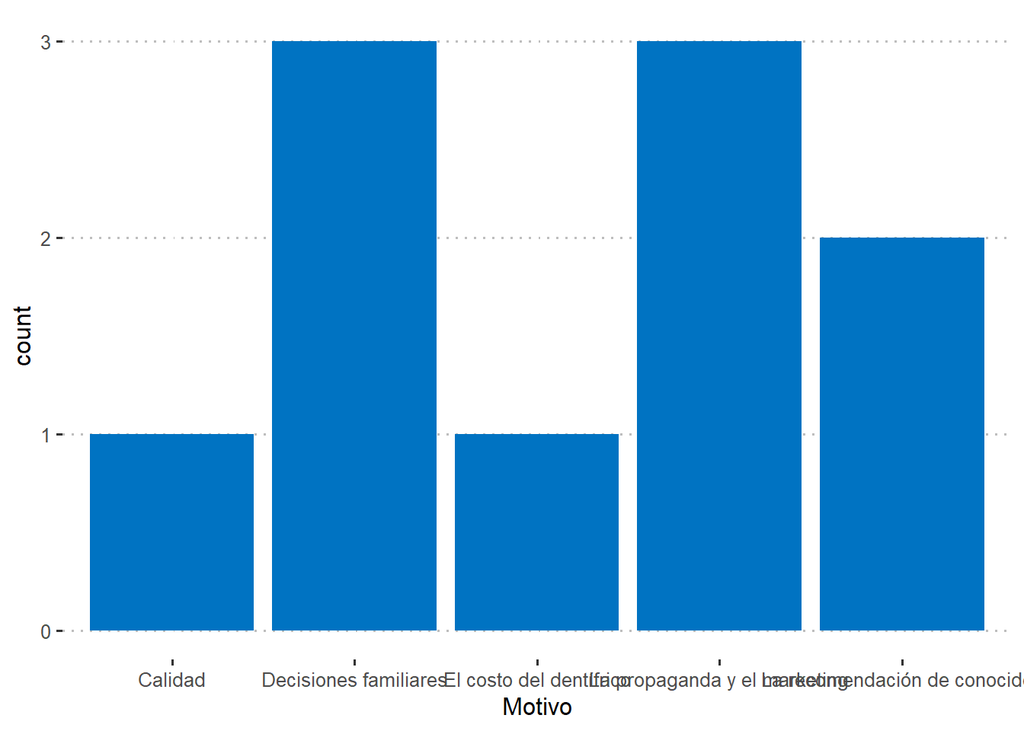

```r
ggplot(Muestra, aes(Motivo)) +
  geom_bar(fill = "#0073C2FF") +
  theme_pubclean()
```

- Posteriormente a la selección de la muestra (Muestro) definimos nuestros parámetros para realizar el modelo probabalístico. Donde:

p = La probabilidad de éxito

```r
Recomendacion <- Encuesta %>% filter(Motivo == "La recomendación de conocidos")
(p = nrow(Recomendacion)/nrow(Encuesta))
```

```
## [1] 0.3186275
```

X: N° de personas que compran un dentrífico por la recomendación de un conocido.

Del cual su rango estará definido por: Rx = {0,1,2,…,10}

A partir de ello podemos establecer el *Modelo binomial*:

[figure not shown]

```r
plot(dbinom(x=0:10, size =20, prob = 0.32),lwd=4,type='h', xlab='x', ylab='Probabilidad', main = "Función de probabilidad binomial para la recomendaciones de dentrífico")
```

- Casos de cálculos:
1. ¿Que tan probable que la mitad o más compren un dentrifico por la recomendación de un conocido?

```r
1-pbinom(4,10,0.32)
```

```
## [1] 0.1866554
```

2. ¿Cuál es el valor esperado del número personas compren un dentrífico por la recomendación de un conocido?

Esperanza = np

```r
(Ex1 = 10*0.3186)
```

```
## [1] 3.186
```

- Resultados obtenidos:

A partir de la función de probabilidad par la variable Motivo se pudo observar que es correcto el análisis obtenido, ya que podemos obtener la probabilidad en un determinado recorrido con la función. Además la esperanza calculada si se aproxima a la cantidad de la muestra seleccionada.